# Weekly Sales Forecast for Big Box, Inc.

Big Box, Inc. requested a forecast of weekly sales for the individual deparments in each of its stores. The company provided the data team with three CSV files containing data related to its stores and their departments, weekly sales, and economic and weather conditions in the geographic areas where stores are located. Specifically Big Box requested a forecast of the next three months beyond the actual sales data provided.

We performed a time series analysis through the following phases:

# Time Series Analysis Phases

1. [Data Import, Validation, and Merge](https://mstuartproj.github.io/sales_forecast/Sales_Forecast_1.html)
2. [Exploratory Data Analysis: Stores, Departments, and Total Sales](https://mstuartproj.github.io/sales_forecast/Sales_Forecast_2.html)
3. [Exploratory Data Analysis: Weekly Sales](https://mstuartproj.github.io/sales_forecast/Sales_Forecast_3.html)
4. [Feature Creation and Selection](https://mstuartproj.github.io/sales_forecast/Sales_Forecast_4.html)
5. [Modeling and Prediction: Random Forest Regression](https://mstuartproj.github.io/sales_forecast/Sales_Forecast_5.html)
6. [Modeling and Prediction: SARIMA](https://mstuartproj.github.io/sales_forecast/Sales_Forecast_6.html)

[figure not shown]

# Phase 2. Exploratory Data Analysis: Stores and Departments

## Type and Sizes of Stores

We created histograms in order to learn about the types and sizes of the company's stores.

We learned these characteristics:

- Most of the stores are Type A and Type B. Fewer stores are Type C.
- The sizes of stores vary greatly. The smallest group and the largest group, together, make up half of the stores.

[figure not shown]

```python
#import the required libraries
import matplotlib.pyplot as plt
import matplotlib.ticker as tick
import numpy as np
import pandas as pd
```

```python
#Read in stores.csv
storesdata = pd.read_csv('data_provided/stores.csv')
```

```
<BarContainer object of 3 artists>
```

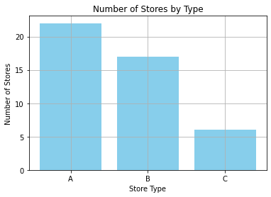

```python
#Create a histogram of stores by type
stores_by_type = storesdata.groupby('Type')['Store'].count().to_frame().reset_index()
plt.title('Number of Stores by Type')
plt.xlabel('Store Type')
plt.ylabel('Number of Stores')
plt.grid()
plt.bar(stores_by_type['Type'],stores_by_type['Store'],color='skyblue')
```

```
<BarContainer object of 8 artists>
```

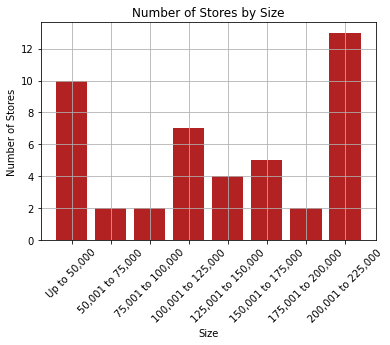

```python
#Create a histogram of stores binned by size
bins = [0, 50000, 75000, 100000, 125000, 150000, 175000, 200000, 225000]
labels = ['Up to 50,000',
          '50,001 to 75,000',
          '75,001 to 100,000',
          '100,001 to 125,000',
          '125,001 to 150,000',
          '150,001 to 175,000',
          '175,001 to 200,000',
          '200,001 to 225,000']
stores_in_bins = storesdata[['Store', 'Size']].copy()
stores_in_bins['Size_Bin'] = pd.cut(storesdata['Size'], bins, labels = labels)
stores_by_size = stores_in_bins.groupby('Size_Bin')['Store'].count().to_frame().reset_index()

#print(stores_by_size)

plt.title('Number of Stores by Size')
plt.xlabel('Size')
plt.ylabel('Number of Stores')
plt.grid()
plt.xticks(rotation = 45)
plt.bar(stores_by_size['Size_Bin'],stores_by_size['Store'], color='firebrick')
```

[figure not shown]

## Total Sales by Store

We created visualiations in order learn about total sales of each store.

We learned these:

- The four stores with the **most** total sales were:
  - Store 20 with sales of \$274.4 million (Type A and size 203,742)
  - Store 4 with sales of \$271.7 million (Type A and size 205,863)
  - Store 14 with sales of \$267.7 million (Type A and size 200,898)
  - Store 13 with sales of \$260.1 million (Type A and size 219,622)
- The three stores with the **least** total sales were:
  - Store 33 with sales of \$33.7 million (Type A and size 39,690)
  - Store 44 with sales of \$38.8 million (Type C and size 39,910)
  - Store 5 with sales of \$41.3 million (Type B and size 34,875)

[figure not shown]

```python
#Read in fulldata.csv
fulldata = pd.read_csv('data_merged/fulldataset.csv', index_col = 0)
```

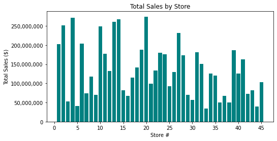

```python
#Graph the sum of the sales for every store
sumsales_by_store = fulldata.groupby('Store')['Weekly_Sales'].sum().to_frame().reset_index()

plt.figure(figsize=(8, 4))
plt.xlabel('Store #')
plt.ylabel('Total Sales ($)')
plt.title('Total Sales by Store')
plt.xticks(np.arange(0, 46, 5))
plt.bar(sumsales_by_store['Store'],sumsales_by_store['Weekly_Sales'],color='teal')
ax = plt.gca()
ax.yaxis.set_major_formatter(tick.FuncFormatter(lambda x, p: format(int(x), ',')));
```

```python
#Find the stores with the most total sales
highsales_by_store = sumsales_by_store[sumsales_by_store['Weekly_Sales'] > 260000000]
highsales_by_store.columns = ['Store', 'High_Total_Sales']
highsales_by_store_sorted = highsales_by_store.sort_values(by=['High_Total_Sales'],ascending=[False])
highsales_by_store_sorted.reset_index(drop=True, inplace=True)
highsales_by_store_sorted
```

|  | Store | High_Total_Sales |
| --- | --- | --- |
| 0 | 20 | 2.744404e+08 |
| 1 | 4 | 2.717064e+08 |
| 2 | 14 | 2.676299e+08 |
| 3 | 13 | 2.601575e+08 |

```python
#Find the stores with the lowest total sales
lowsales_by_store = sumsales_by_store[sumsales_by_store['Weekly_Sales'] < 45000000]
lowsales_by_store.columns = ['Store', 'Low_Total_Sales']
lowsales_by_store_sorted = lowsales_by_store.sort_values(by=['Low_Total_Sales'])
lowsales_by_store_sorted.reset_index(drop=True, inplace=True)
lowsales_by_store_sorted
```

|  | Store | Low_Total_Sales |
| --- | --- | --- |
| 0 | 33 | 33724296.30 |
| 1 | 44 | 38874431.76 |
| 2 | 5 | 41296045.84 |

[figure not shown]

## Total Sales by Department

We created visualiations in order learn about the company's sales by department over all stores.

[figure not shown]

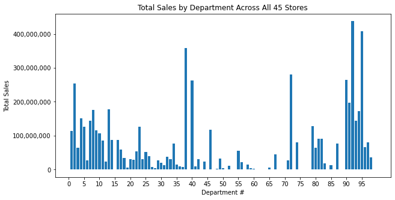

```python
#Graph the sum of sales for every department (over all stores)
sumsales_by_dept = fulldata.groupby('Dept')['Weekly_Sales'].sum().to_frame().reset_index()

plt.figure(figsize=(10, 5))
plt.xlabel('Department #')
plt.ylabel('Total Sales')
plt.title('Total Sales by Department Across All 45 Stores')
plt.xticks(np.arange(0, 100, 5))
plt.bar(sumsales_by_dept['Dept'],sumsales_by_dept['Weekly_Sales'])
ax = plt.gca()
ax.yaxis.set_major_formatter(tick.FuncFormatter(lambda x, p: format(int(x), ',')));
```

```python
#Find the departments with the most sales across all stores
highsales_by_dept = sumsales_by_dept[sumsales_by_dept['Weekly_Sales'] > 300000000]
highsales_by_dept.columns = ['Dept', 'High_Total_Sales']
highsales_by_dept_sorted = highsales_by_dept.sort_values(by=['High_Total_Sales'],ascending=[False])
highsales_by_dept_sorted.reset_index(drop=True, inplace=True)
highsales_by_dept_sorted
```

|  | Dept | High_Total_Sales |
| --- | --- | --- |
| 0 | 92 | 4.374923e+08 |
| 1 | 95 | 4.075111e+08 |
| 2 | 38 | 3.582909e+08 |

```python
#Find the departments with the lowest sales across all stores
lowsales_by_dept = sumsales_by_dept[sumsales_by_dept['Weekly_Sales'] < 10000]
lowsales_by_dept.columns = ['Dept', 'Low_Total_Sales']
lowsales_by_dept_sorted = lowsales_by_dept.sort_values(by=['Low_Total_Sales'])
lowsales_by_dept_sorted.reset_index(drop=True, inplace=True)
lowsales_by_dept_sorted
```

|  | Dept | Low_Total_Sales |
| --- | --- | --- |
| 0 | 47 | -4654.25 |
| 1 | 43 | 14.32 |
| 2 | 39 | 40.90 |
| 3 | 78 | 1711.71 |